# Big data analytics

Ridge Regression and the Lasso

O.Klopp

[figure not shown]

We will use Hitters data set from ISLR package. ISLR package must be downloaded the first time using install.packages(“ISLR”)

```r
library(ISLR)# loading the ISLR package
names(Hitters)
```

```
##  [1] "AtBat"     "Hits"      "HmRun"     "Runs"      "RBI"
##  [6] "Walks"     "Years"     "CAtBat"    "CHits"     "CHmRun"
## [11] "CRuns"     "CRBI"      "CWalks"    "League"    "Division"
## [16] "PutOuts"   "Assists"   "Errors"    "Salary"    "NewLeague"
```

```r
dim(Hitters)
```

```
## [1] 322  20
```

Checking for missing values:

```r
sum(is.na(Hitters$Salary))
```

```
## [1] 59
```

```r
Hitters = na.omit(Hitters)
dim(Hitters)
```

```
## [1] 263  20
```

```r
sum(is.na(Hitters$Salary))
```

```
## [1] 0
```

# 1.1 Ridge Regression

We will use the glmnet package in order to perform the ridge regression and the lasso. The glmnet package must be downloaded the first time using install.packages(“glmnet”, repos = “http://cran.us.r-project.org”)

The main function in this package is glmnet(). For this function we must pass in an x matrix as well as a y vector:

```r
x=model.matrix(Salary~.,Hitters)[,-1]# [,-1] removes intersept column
y=Hitters$Salary
head(x)# Returns the first or last parts of the model.matrix
```

```
##                   AtBat Hits HmRun Runs RBI Walks Years CAtBat CHits
## -Alan Ashby         315   81     7   24  38    39    14   3449   835
## -Alvin Davis        479  130    18   66  72    76     3   1624   457
## -Andre Dawson       496  141    20   65  78    37    11   5628  1575
## -Andres Galarraga   321   87    10   39  42    30     2    396   101
## -Alfredo Griffin    594  169     4   74  51    35    11   4408  1133
## -Al Newman          185   37     1   23   8    21     2    214    42
##                   CHmRun CRuns CRBI CWalks LeagueN DivisionW PutOuts
## -Alan Ashby           69   321  414    375       1         1     632
## -Alvin Davis          63   224  266    263       0         1     880
## -Andre Dawson        225   828  838    354       1         0     200
## -Andres Galarraga     12    48   46     33       1         0     805
## -Alfredo Griffin      19   501  336    194       0         1     282
## -Al Newman             1    30    9     24       1         0      76
##                   Assists Errors NewLeagueN
## -Alan Ashby            43     10          1
## -Alvin Davis           82     14          0
## -Andre Dawson          11      3          1
## -Andres Galarraga      40      4          1
## -Alfredo Griffin      421     25          0
## -Al Newman            127      7          0
```

We first fit a ridge regression model:

```r
library(glmnet)
grid=10^seq(10,-2,length=100)#implement the rigide regression over a grid of values
ridge.mod=glmnet(x,y,alpha=0,lambda=grid)# If alpha=0 then a ridge regression model is fit
```

```r
dim(coef(ridge.mod))
```

```
## [1]  20 100
```

```r
ridge.mod$lambda[50]
```

```
## [1] 11497.57
```

Coefficients when λ = 11,498:

```r
coef(ridge.mod)[,50]
```

```
##   (Intercept)         AtBat          Hits         HmRun          Runs
## 407.356050200   0.036957182   0.138180344   0.524629976   0.230701523
##           RBI         Walks         Years        CAtBat         CHits
##   0.239841459   0.289618741   1.107702929   0.003131815   0.011653637
##        CHmRun         CRuns          CRBI        CWalks       LeagueN
##   0.087545670   0.023379882   0.024138320   0.025015421   0.085028114
##     DivisionW       PutOuts       Assists        Errors    NewLeagueN
##  -6.215440973   0.016482577   0.002612988  -0.020502690   0.301433531
```

Their l_2 norm:

```r
sqrt(sum(coef(ridge.mod)[-1,50]^2))# without intersept
```

```
## [1] 6.360612
```

Coefficients when λ = 705

```r
ridge.mod$lambda[60]
```

```
## [1] 705.4802
```

```r
coef(ridge.mod)[,60]
```

```
##  (Intercept)        AtBat         Hits        HmRun         Runs
##  54.32519950   0.11211115   0.65622409   1.17980910   0.93769713
##          RBI        Walks        Years       CAtBat        CHits
##   0.84718546   1.31987948   2.59640425   0.01083413   0.04674557
##       CHmRun        CRuns         CRBI       CWalks      LeagueN
##   0.33777318   0.09355528   0.09780402   0.07189612  13.68370191
##    DivisionW      PutOuts      Assists       Errors   NewLeagueN
## -54.65877750   0.11852289   0.01606037  -0.70358655   8.61181213
```

```r
sqrt(sum(coef(ridge.mod)[-1,60]^2))# without intersept
```

```
## [1] 57.11001
```

Use the predict() function to obtain the ridge regression coefficients for a new value of λ=50:

```r
predict(ridge.mod,s =50, type="coefficients") [1:20,]
```

```
##   (Intercept)         AtBat          Hits         HmRun          Runs
##  4.876610e+01 -3.580999e-01  1.969359e+00 -1.278248e+00  1.145892e+00
##           RBI         Walks         Years        CAtBat         CHits
##  8.038292e-01  2.716186e+00 -6.218319e+00  5.447837e-03  1.064895e-01
##        CHmRun         CRuns          CRBI        CWalks       LeagueN
##  6.244860e-01  2.214985e-01  2.186914e-01 -1.500245e-01  4.592589e+01
##     DivisionW       PutOuts       Assists        Errors    NewLeagueN
## -1.182011e+02  2.502322e-01  1.215665e-01 -3.278600e+00 -9.496680e+00
```

Split the samples into a training set and a test set in order to estimate the test error of ridge regression and the lasso:

```r
set.seed(1)
train=sample(1:nrow(x),nrow(x)/2)#note 1
test =(- train)#Note 2
y.test = y [ test ]
#note1: sample takes a sample of the size nrow(x)/2 from the set {1,...,nrow(x)}
#Note 2: we put in the test set indices that are not in the train set
```

We fit a ridge regression model on the training set, and evaluate its MSE on the test set, using λ = 4:

```r
ridge.mod = glmnet(x[train,],y[train],alpha =0,lambda = grid)
ridge.pred = predict(ridge.mod,s =4,newx=x[test,])
mean((ridge.pred-y.test)^2)
```

```
## [1] 101186.3
```

Fitting a model using the mean of the training observations:

```r
mean((mean(y[train])-y.test)^2)# computing the test set MSE
```

```
## [1] 193253.1
```

We get essentially the same result by fitting a ridge regression model with a very large value of λ:

```r
ridge.pred=predict(ridge.mod,s=1e10,newx=x[test,])
mean((ridge.pred-y.test)^2)
```

```
## [1] 193253.1
```

Check whether there is any benefit to performing ridge regression with λ = 4 instead of just performing least squares regression:

```r
ridge.pred=predict(ridge.mod,x=x[train,],y=y[train],s =0,newx=x[test,],exact=T)#Note 1
mean ((ridge.pred-y.test)^2)
```

```
## [1] 115899.1
```

```r
#Note 1: In order for glmnet() to yield the exact least squares coefficients when λ = 0, we use the argument exact=T when calling the predict() function. Otherwise, the predict() function will interpolate over the grid of λ values used in fitting the glmnet() model, yielding approximate results.
```

Using cross-validation to choose the tuning parameter λ:

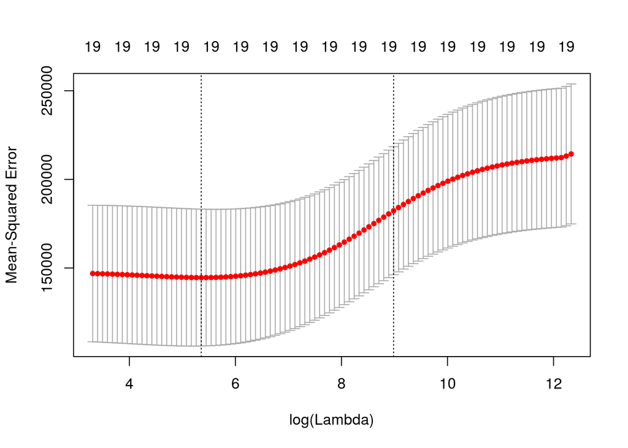

```r
set.seed (1)
cv.out=cv.glmnet(x[train,],y[train],alpha =0)
plot(cv.out)
```

```r
bestlam=cv.out$lambda.min
bestlam
```

```
## [1] 211.7416
```

The test MSE associated with λ=211.7416:

```r
ridge.pred=predict(ridge.mod,s = bestlam,newx = x [test,])
mean((ridge.pred-y.test)^2)
```

```
## [1] 96012.47
```

We refit our ridge regression model on the full data set, using the value of λ chosen by cross-validation:

```r
out=glmnet(x,y,alpha =0)
predict(out,type="coefficients",s = bestlam) [1:20,]# we examine the coefficient estimates
```

```
##  (Intercept)        AtBat         Hits        HmRun         Runs
##   9.88487157   0.03143991   1.00882875   0.13927624   1.11320781
##          RBI        Walks        Years       CAtBat        CHits
##   0.87318990   1.80410229   0.13074381   0.01113978   0.06489843
##       CHmRun        CRuns         CRBI       CWalks      LeagueN
##   0.45158546   0.12900049   0.13737712   0.02908572  27.18227535
##    DivisionW      PutOuts      Assists       Errors   NewLeagueN
## -91.63411299   0.19149252   0.04254536  -1.81244470   7.21208390
```

# 1.2 The Lasso

In order to fit a lasso model, we use the glmnet() function:

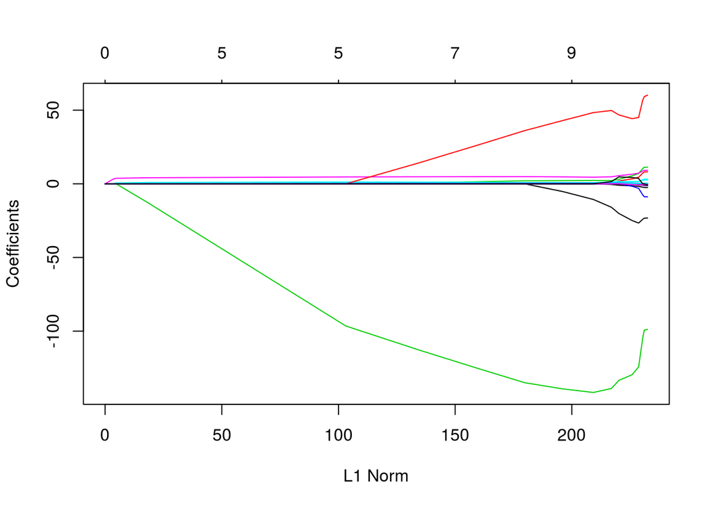

```r
lasso.mod=glmnet(x[train,],y[train],alpha=1,lambda=grid)# we use the argument alpha=1 for lasso
plot (lasso.mod)# the coefficients plotted as function of l_1 norm
```

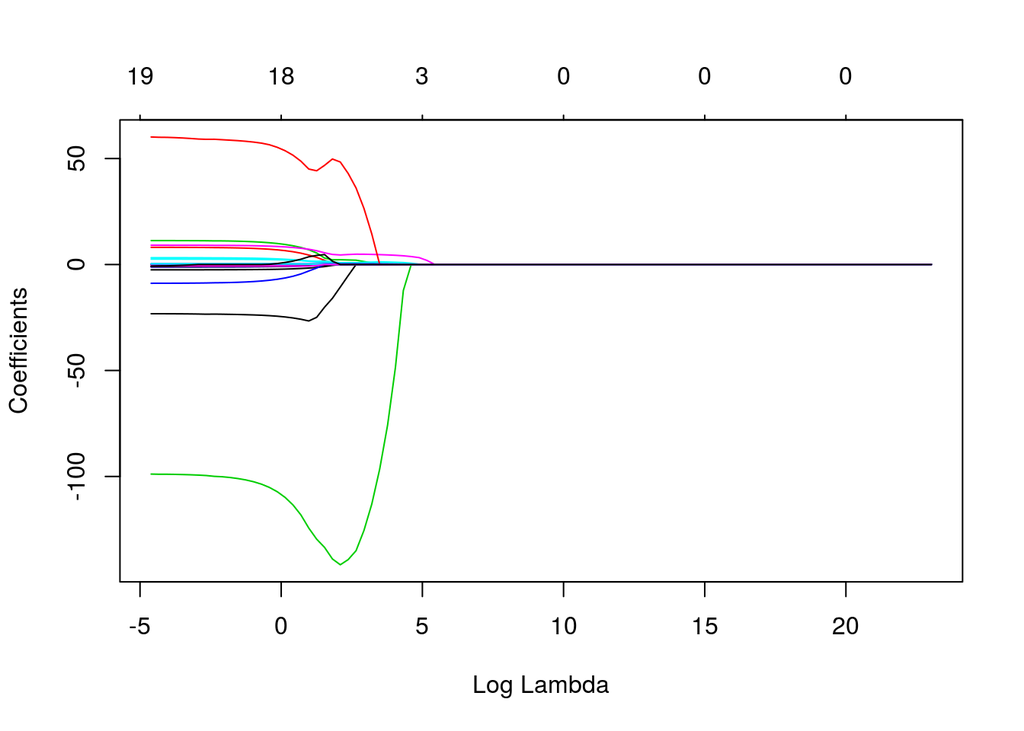

```r
plot(lasso.mod,"lambda")# the coefficients plotted as function of log(lambda)
```

Cross-validation:

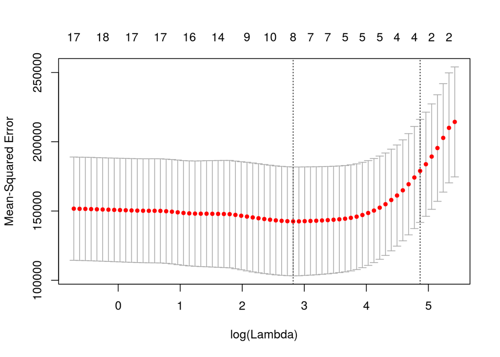

```r
set.seed(1)
cv.out=cv.glmnet(x[train,],y[train],alpha=1)
plot(cv.out)
```

The associated test error:

```r
bestlam = cv.out$lambda.min
lasso.pred=predict(lasso.mod,s = bestlam,newx=x[test,])
mean((lasso.pred-y.test)^2)
```

```
## [1] 100743.4
```

```r
out=glmnet(x,y,alpha=1,lambda = grid)
lasso.coef=predict(out,type="coefficients",s=bestlam) [1:20 ,]
lasso.coef
```

```
##  (Intercept)        AtBat         Hits        HmRun         Runs
##   18.5394844    0.0000000    1.8735390    0.0000000    0.0000000
##          RBI        Walks        Years       CAtBat        CHits
##    0.0000000    2.2178444    0.0000000    0.0000000    0.0000000
##       CHmRun        CRuns         CRBI       CWalks      LeagueN
##    0.0000000    0.2071252    0.4130132    0.0000000    3.2666677
##    DivisionW      PutOuts      Assists       Errors   NewLeagueN
## -103.4845458    0.2204284    0.0000000    0.0000000    0.0000000
```

```r
lasso.coef[lasso.coef!=0]# non-zero coefficients
```

```
##  (Intercept)         Hits        Walks        CRuns         CRBI
##   18.5394844    1.8735390    2.2178444    0.2071252    0.4130132
##      LeagueN    DivisionW      PutOuts
##    3.2666677 -103.4845458    0.2204284
```